# Simulating Data using a Discrete-Event Approach

Robin Denz

# Introduction

In this small vignette, we introduce the `sim_discrete_event()` function, which can be used to generate complex longitudinal data with a continuous time scale based on the discrete-event simulation (DES) framework (Banks et al. 2014). It is very similar to the `sim_discrete_time()` function in spirit, but relies on a completely different algorithm to generate the data. This algorithm is usually much faster than the discrete-time approach, while also being more precise. The drawback is some added complexity and a little less flexibility. For example, in `sim_discrete_event()`, continuous, categorical or count-based time-dependent variables are currently not supported. Only binary variables added using the `"next_time"` node type may be used.

The goal of the `sim_discrete_event()` function is not to provide a general framework for DES. Multiple other R packages, such as `simmer` (Ucar, Smeets, and Azcorra 2019; Degeling et al. 2025) and `DES` (Matloff 2017), as well as software packages outside R have been developed for that purpose and are much more useful in this regard. Instead, the aim of this function is to provide a specific, but fairly general, DES model that may be used to generate data from DAG based description of the data generation process (DGP). In other words: if you want to perform a classic DES with interacting agents using a classic simulation modeling approach, this is probably not the right package for you. If you want to generate complex time-dependent data based on a stochastic model, you have come to the right place.

Throughout the vignette, we assume that the reader is already familiar with the `simDAG` syntax. If this is not the case, we recommend consulting the introductory vignette or the main paper associated with this package first (Denz and Timmesfeld 2026).

# What is Discrete-Event Simulation and Why Use it?

In a discrete-event simulation (DES), the data is generated according to a statistical model, which describes a system as a sequence of distinct (or discrete) events that happen in continuous time and may influence each other. Any DES starts with the generation of $n$ individuals at $t = 0$ that have some characteristics, such as values of multiple covariates. The full description of all individuals is considered to be the *state* of the simulation here. This *state* only ever changes when some *event* occurs. A simple example for an *event* would be a variable changing its value from `FALSE` to `TRUE` or vice versa. If such an event occurs, the time of the simulation is advanced to the timing of this event. The state of the simulation is then updated to reflect the changes brought on by this event. Next, the time until the next event is generated and the process is repeated until some condition is met. The flowchart below gives a generalized description of a DES as considered here.

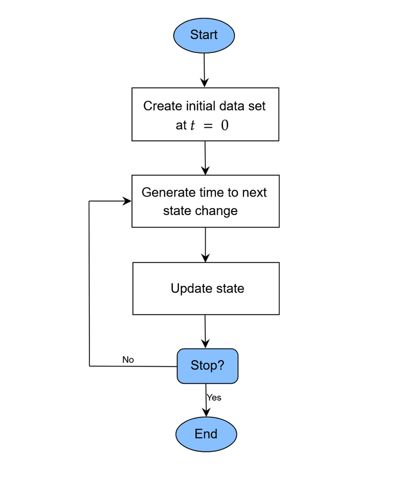

A generalized flow-chart of the discrete-event simulation approach

This approach has many names and usages in the literature. In physics and chemistry, the particular variant discussed here is known as the Gillespie algorithm (Gillespie 1976, 1977), or the *next reaction* or *first reaction* method (Anderson 2007). Formally, it is a mathematically exact method to generate random trajectories from a known (not necessarily Markovian) stochastic process (Masuda and Rocha 2018). Formal descriptions of the algorithm are given in the cited literature. The most general description of the DES (or Gillespie algorithm) implemented in `sim_discrete_event()` is as follows for every individual:

- 1. At $t = 0$, initialize the baseline covariate values and set all $m$ time-dependent covariates to `FALSE`.
- 2. For each of the $m$ considered time-dependent variables, generate the time until the next change based on some distributional assumptions (possibly dependent on any variables contained in the current state)
- 3. Advance the simulation to the minimum of the values drawn in step (2).
- 4. Update the value of the time-dependent variable that generated this event.
- 5. Go back to step (2) and repeat until either some condition is met or no changes are possibly anymore (may happen if every time-dependent variable has reached a terminal state).

The `sim_discrete_event()` directly implements this workflow, assuming that individuals (rows in the `data`) do not influence each other. A data set at $t = 0$ is either simulated using the `sim_from_dag()` function or supplied directly by the user (using the `t0_data` argument). This data set is then updated according to the time-dependent nodes added to the `dag` using `node_td()` calls. After each update, the state of the simulation is saved, so that the final output is a single dataset in the start-stop format. Below we give a short example on how this works in practice. We use a similar example to the one used in the discrete-time simulation vignette, to allow direct comparisons with the discrete-time approach.

# Defining the DAG

As for the other simulation functions in this package, the definition of a DAG is the first required step. Any amount of time-independent variables specified using standard `node()` function calls are supported. Time-dependent nodes should be specified using the `node_td()` function instead. Importantly, for `sim_discrete_event()`, only time-dependent nodes of type `"next_time"` are supported. For more examples and guidance on how to generally define a DAG, please consult the other vignettes and documentation pages of this package.

# A single time-dependent variable

For illustrative purposes, we will start with a small comparison of the discrete-time simulation approach and the discrete-event approach. Consider that we are interested in simulating the time until `death` for $n$ individuals. Lets ignore the influence of any other variables for the moment and just consider `death` by itself. Suppose that `death` has a fixed probability of 0.01 to occur during each time-unit.

## Discrete-Time approach

In a discrete-time simulation, we would simply draw Bernoulli trials with a probability of 0.01 at $t$. If the trial returns a 1, we are done and save the time. If it returns a 0, we increase $t$ by one and repeat until we are finished. This can be done using the `sim_discrete_time()` function using the following code:

```r
library(simDAG)
library(data.table)
library(ggplot2)

set.seed(1234)

dag_dts <- empty_dag() +
  node_td("death", type="time_to_event", prob_fun=0.01, event_duration=Inf)

simDTS <- sim_discrete_time(dag_dts, n_sim=10, max_t=10000000,
                            break_if=all(data$death_event==TRUE))
head(simDTS$data)
```

```
#>      .id death_event death_time
#>    <int>      <lgcl>      <int>
#> 1:     1        TRUE         98
#> 2:     2        TRUE         20
#> 3:     3        TRUE         13
#> 4:     4        TRUE        112
#> 5:     5        TRUE         36
#> 6:     6        TRUE         54
```

Here, we set the `max_t` argument to a very large number and told the function to stop once everyone has died using the `break_if` argument. This approach works well, but it is also incredibly inefficient in this simple example. Since `death` has a constant probability of 0.01, we could also simply sample time values from an exponential distribution with `rate=0.01`. This is exactly what will be exploited in the DES approach.

## Discrete-Event approach

Since we are only interested in a single variable, which has a terminal state (once you are dead, there is no going back), we only need one time-jump and thus only one iteration in the DES approach, while we needed potentially hundreds or thousands in the discrete-time approach. The following code may be used to implement this:

```r
dag_des <- empty_dag() +
  node_td("death", type="next_time", prob_fun=0.01, event_duration=Inf)

simDES <- sim_discrete_event(dag_des, n_sim=10, target_event="death",
                             keep_only_first=TRUE)
head(simDES)
```

```
#> Key: <.id, start>
#>      .id start       stop  death
#>    <int> <num>      <num> <lgcl>
#> 1:     1     0 102.242570   TRUE
#> 2:     2     0 140.148734   TRUE
#> 3:     3     0 104.549136   TRUE
#> 4:     4     0  91.690158   TRUE
#> 5:     5     0   1.877996   TRUE
#> 6:     6     0 147.742697   TRUE
```

There are some differences to the output of the `sim_discrete_time()` function. First, because we are using the DES approach, the time is continuous and not discrete. Secondly, the output is naturally in the start-stop format, because there would be no other useful way to represent it. Because there is only one change, each individual only has one row in the dataset and it is thus still almost equivalent to the output of the discrete-time approach.

In this example the `sim_discrete_event()` output is exactly equal to just calling `rexp(10, rate=0.01)`, while the `sim_discrete_time()` output is a discrete-time approximation to it.

# Two interrelated time-dependent variables

We will now make the example a little more complex, by including a time-dependent variable which directly influences the probability of death. Consider the following code:

```r
prob_death <- function(data) {
  0.001 * 0.8^(data$treatment)
}

dag <- empty_dag() +
  node_td("treatment", type="next_time", prob_fun=0.01,
          event_duration=100) +
  node_td("death", type="next_time", prob_fun=prob_death,
          event_duration=Inf)

sim <- sim_discrete_event(dag, n_sim=10, remove_if=death==TRUE,
                          target_event="death", keep_only_first=TRUE)
```

Here, we specified two time-dependent nodes of type `"next_time"`. The first one denotes the `treatment`, which has a fixed probability of being given to a person. It then has an effect for 100 time units, after which the variable turns back to `FALSE`. Once it is `FALSE` again, it may be given to the same person again immediately, with a probability of 0.01. The probability of the `death` of a person is now no longer fixed, but a function of the `treatment` status. The general probability of death is 0.001 per time unit, but it is reduced by a factor of 0.8 if the `treatment` is currently in effect.

Importantly, in this simulation we had to use one of the three arguments that define an end of the simulation: `max_t`, `remove_if` or `break_if`. We specified `remove_if`, so that all individuals who die are no longer part of the simulation. Alternatively, we could have gotten a similar effect using the `break_if` argument, or limit the amount of time the simulation may run with `max_t`. The latter is not very useful here, because we are interested in the time of death. If we hadn’t used any of these arguments, the simulation would be updated exactly `1000` times per person (default value of the `max_iter` argument), because `treatment` does not have a terminal state (both its `event_duration` and `immunity_duration` are finite). The `target_event` argument is only used to make the output a little prettier.

The generated data for the first individual look like this:

```r
head(sim, 9)
```

```
#> Key: <.id, start>
#>      .id     start      stop treatment  death
#>    <int>     <num>     <num>    <lgcl> <lgcl>
#> 1:     1   0.00000  15.65804     FALSE  FALSE
#> 2:     1  15.65804 115.65804      TRUE  FALSE
#> 3:     1 115.65804 168.33340     FALSE  FALSE
#> 4:     1 168.33340 268.33340      TRUE  FALSE
#> 5:     1 268.33340 420.23653     FALSE  FALSE
#> 6:     1 420.23653 520.23653      TRUE  FALSE
#> 7:     1 520.23653 606.02564     FALSE  FALSE
#> 8:     1 606.02564 706.02564      TRUE  FALSE
#> 9:     1 706.02564 860.85932     FALSE   TRUE
```

As can be seen, the treatment keeps switching between `TRUE` and `FALSE` until the `death` is eventually reached. If we increased `n_sim` and fit a Cox proportional hazards regression model with the time-to `death` as the endpoint and the `treatment` as covariate, we would be able to recover the 0.8 as the hazard ratio for the treatment. The same strategy could of course be used for any amount of time-varying variables.

Above, we used the `prob_fun` argument to specify the probabilities, so that the connection to the `sim_discrete_time()` approach is more clear. Alternatively, we could also use the much more convenient `formula` interface:

```r
dag <- empty_dag() +
  node_td("treatment", type="next_time", prob_fun=0.01,
          event_duration=100) +
  node_td("death", type="next_time",
          formula= ~ log(0.001) + log(0.8)*treatment, link="log",
          event_duration=Inf)

sim <- sim_discrete_event(dag, n_sim=10, remove_if=death==TRUE,
                          target_event="death", keep_only_first=TRUE)
```

Here, we simply specified the log-binomial model as one would when specifying a simple binomial regression model (see `?node_binomial`). Note that although the results are theoretically equivalent when the same seed is used, they are not identical in practice, due to small floating point errors. This should not be an issue in practice.

# Some things to consider

## Time-Dependent probabilities and effects

By default, the time until the next event is generated using a random draw from an exponential distribution. This approach, however, assumes that the probability of occurrence is independent of the time. We can relax this assumption in multiple ways. The most simply way is to use the `redraw_at_t` argument. This argument allows users to specify points in time at which the time to the next event should be re-drawn. By additionally making the probability function supplied to a time-dependent node time-specific, we can then use a piecewise-constant baseline event probability, instead of a truly constant one. Consider the following code:

```r
prob_death <- function(data) {
  base_p <- fifelse(data$.time > 300, 0.005, 0.001)
  base_p * 0.8^(data$treatment)
}

dag <- empty_dag() +
  node_td("treatment", type="next_time", prob_fun=0.01,
          event_duration=100) +
  node_td("death", type="next_time", prob_fun=prob_death,
          event_duration=Inf)

sim <- sim_discrete_event(dag, n_sim=10, remove_if=death==TRUE,
                          target_event="death", redraw_at_t=300,
                          keep_only_first=TRUE)
head(sim)
```

```
#> Key: <.id, start>
#>      .id     start      stop treatment  death
#>    <int>     <num>     <num>    <lgcl> <lgcl>
#> 1:     1   0.00000  32.13286     FALSE  FALSE
#> 2:     1  32.13286 132.13286      TRUE  FALSE
#> 3:     1 132.13286 300.00000     FALSE  FALSE
#> 4:     1 300.00000 440.08265     FALSE  FALSE
#> 5:     1 440.08265 540.08265      TRUE  FALSE
#> 6:     1 540.08265 648.71324     FALSE  FALSE
```

In this code, the baseline probability is 0.001 until $t = 300$ and then increases to 0.005. It is not sufficient to only define the probability function this way, because then there would be no way for the simulation itself to know that the event durations have to be re-drawn. For example, lets say the `death` time drawn at $t = 0$ for some person is 678 and assume that `treatment` has no effect for this individual. This time was generated using a rate of 0.001, so only the time until 300 is valid. At $t = 300$, we therefore have to re-draw another time from a truncated exponential distribution with the new rate of 0.005 (truncated at 300).

The same strategy could be used to define piecewise-constant time-dependent effects as well. One would only need to adjust the `prob_death()` function so that it has a different factor for `treatment` depending on the time. Using continuously changing probabilities is also possible, but requires a different approach. The easiest way to do this is by using the `model` argument. Consider the code below:

```r
dag <- empty_dag() +
  node_td("treatment", type="next_time", prob_fun=0.01,
          event_duration=100) +
  node_td("death", type="next_time",
          formula= ~ log(0.8)*treatment, model="cox",
          surv_dist="weibull", gamma=1.5, lambda=0.0001,
          event_duration=Inf)

sim <- sim_discrete_event(dag, n_sim=10, remove_if=death==TRUE,
                          target_event="death", keep_only_first=TRUE)
head(sim)
```

```
#> Key: <.id, start>
#>      .id     start      stop treatment  death
#>    <int>     <num>     <num>    <lgcl> <lgcl>
#> 1:     1   0.00000  40.59338     FALSE  FALSE
#> 2:     1  40.59338 140.59338      TRUE  FALSE
#> 3:     1 140.59338 171.25288     FALSE  FALSE
#> 4:     1 171.25288 271.25288      TRUE  FALSE
#> 5:     1 271.25288 314.34103     FALSE  FALSE
#> 6:     1 314.34103 414.34103      TRUE  FALSE
```

Here, we use a Cox proportional hazards model with a Weibull baseline hazard function to generate the time of `death` instead of directly defining the probability functions and drawing values using an exponential distribution. Since the Weibull distribution is not constant over time, this is a valid strategy if we want continuously changing baseline event probabilities.

Since `node_cox()` (the function that is used to generate the times following a Cox model under the hood) allows users to specify arbitrary baseline hazard functions, users may use any kind of time-dependent probabilities. For example, lets define this arbitrary baseline hazard for `death`:

```r
fbasehaz <- function(t) {
  0.0002 +
    0.001 * exp(-((t - 200)^2) / (2 * 50^2)) + # first hill
    0.0008 * exp(-((t - 700)^2) / (2 * 80^2))  # second hill
}
```

Plotted, it looks like this for the first 1000 time units:

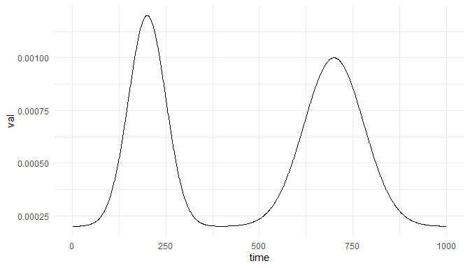

```r
plotdata <- data.frame(time=1:1000, val=fbasehaz(1:1000))

ggplot(plotdata, aes(x=time, y=val)) +
  geom_line() +
  theme_minimal()
```

We can use this function as a baseline hazard for `death` through the `surv_dist` argument of `node_cox()` like this:

```r
dag <- empty_dag() +
  node_td("treatment", type="next_time", prob_fun=0.01,
          event_duration=100, immunity_duration=Inf) +
  node_td("death", type="next_time",
          formula= ~ log(0.8)*treatment, model="cox",
          surv_dist=fbasehaz, basehaz_grid=1:1000000,
          event_duration=Inf, extrapolate=TRUE)

sim <- sim_discrete_event(dag, n_sim=10, remove_if=death==TRUE,
                          target_event="death", keep_only_first=TRUE,
                          max_t=10000)
head(sim)
```

```
#> Key: <.id, start>
#>      .id     start       stop treatment  death
#>    <int>     <num>      <num>    <lgcl> <lgcl>
#> 1:     1   0.00000   10.02079     FALSE  FALSE
#> 2:     1  10.02079  110.02079      TRUE  FALSE
#> 3:     1 110.02079 1487.77199     FALSE   TRUE
#> 4:     2   0.00000   60.61419     FALSE  FALSE
#> 5:     2  60.61419  160.61419      TRUE  FALSE
#> 6:     2 160.61419 4432.02708     FALSE   TRUE
```

Internally, the time to `death` is now generated by following steps: (1) numerically calculating the cumulative baseline hazard using the trapezoid rule over the grid of time points specified using `basehaz_grid`, (2) interpolating the increments linearly to obtain a smooth function, (3) inverting the estimated cumulative hazard function, (4) simulating cumulative hazards from the defined model and (5) reading off the corresponding survival time through the inverted cumulative hazard function. Note that this method can only generate data up to `max(basehaz_grid)`.

In theory, the same strategy could be used for any other time-to-event model, such as Aalen additive hazards models, accelerated failure time models etc. Users only need a function that simulates data from such models and directly allows left-truncation. Although many of these models are supported through the `model` argument, only the Cox model currently allows completely flexible baseline hazard definitions.

# Discussion

The `sim_discrete_event()` function has multiple advantages over its sibling, the `sim_discrete_time()` function. As a general rule, if a DGP can be described in terms of only binary time-dependent variables (plus an arbitrary amount of time-constant variable) it should be possibly to use both functions. In this case, the `sim_discrete_event()` approach is often much faster and more efficient and thus preferable. If more complex data is required, the discrete-time simulation approach offers more flexibility, while also being easier to understand, at the cost of computational time.

# References

Anderson, David F. 2007. “A Modified Next Reaction Method for Simulating Chemical Systems with Time Dependent Propensities and Delays.” *The Journal of Chemical Physics* 127 (21).

Banks, Jerry, John S. Carson II, Barry L. Nelson, and David M. Nicol. 2014. *Discrete-Event System Simulation*. Vol. 5. Edinburgh Gate: Pearson Education Limited.

Degeling, Koen, Jonathan Karnon, Michiel van de Ven, alan Brennan, and Hendrik Koffijberg. 2025. “Discrete Event Simulation in r Using the ’Simmer’ Package for Health Economic Modelling: A Tutorial and Illustration in Colon Cancer.” *Applied Health Economics and Health Policy* 23: 961–75.

Denz, Robin, and Nina Timmesfeld. 2026. “Simulating Complex Cross-Sectional and Longitudinal Data Using the simDAG R Package.” *Journal of Statistical Software* 116 (2): 1–40. https://doi.org/10.18637/jss.v116.i02.

Gillespie, Daniel T. 1976. “A General Method for Numerically Simulating the Stochastic Time Evolution of Coupled Chemical Reactions.” *Journal of Computational Physics* 22 (4): 403–34.

———. 1977. “Exact Stochastic Simulation of Coupled Chemical Reactions.” *The Journal of Physical Chemistry* 81 (25): 2340–61.

Masuda, Naoki, and Luis E. C. Rocha. 2018. “A Gillespie Algorithm for Non-Markovian Stochastic Processes.” *SIAM Review* 60 (1): 95–115.

Matloff, Norm. 2017. *DES: Discrete Event Simulation*. https://doi.org/10.32614/CRAN.package.DES.

Ucar, Iñaki, Bart Smeets, and Arturo Azcorra. 2019. “Simmer: Discrete-Event Simulation for r.” *Journal of Statistical Software* 90 (2). https://doi.org/10.18637/jss.v090.i02.